# Introduction to ltmle()

Yazhuo Deng

January 21, 2019

- • A Anodes (treatment)
- • C Cnodes (censoring)
- • L Lnodes (time-varying covariates)
- • Y Ynodes (events)
- • AC Anodes and Cnodes combined and sorted
- • LY Lnodes and Ynodes combined, sorted, “blocks” removed

## 0.1 ltmle()

ltmle(data, Anodes, Cnodes = NULL, Lnodes = NULL, Ynodes, survivalOutcome = NULL, Qform = NULL, gform = NULL, abar, rule = NULL, gbounds = c(0.01, 1), Yrange = NULL, deterministic.g.function = NULL, stratify = FALSE, SL.library = “glm”, SL.cvControl = list(), estimate.time = TRUE, gcomp = FALSE, iptw.only = FALSE, deterministic.Q.function = NULL, variance.method = “tmle”, observation.weights = NULL, id = NULL)

- Required:
  - data
  - Anodes
  - Ynodes
  - abar
- Often needed:
  - Cnodes
  - Lnodes
  - SL.library
  - survivalOutcome
- Rarely needed (simple):
  - gbounds
  - Yrange
  - stratify
  - SL.cvControl
  - estimate.time
  - gcomp
  - iptw.only
  - variance.method
  - observation.weights
  - id
- Rarely needed (complicated):
  - Qform
  - gform
  - rule
  - deterministic.g.function
  - deterministic.Q.function

## 0.2 ltmleMSM()

ltmleMSM(data, Anodes, Cnodes = NULL, Lnodes = NULL, Ynodes, survivalOutcome = NULL, Qform = NULL, gform = NULL, gbounds = c(0.01, 1), Yrange = NULL, deterministic.g.function = NULL, SL.library = “glm”, SL.cvControl = list(), regimes, working.msm, summary.measures, final.Ynodes = NULL, stratify = FALSE, msm.weights = “empirical”, estimate.time = TRUE, gcomp = FALSE, iptw.only = FALSE, deterministic.Q.function = NULL, variance.method = “tmle”, observation.weights = NULL, id = NULL)

- Required:
  - data
  - Anodes
  - Ynodes
  - regimes
  - working.msm
  - summary.measures
- Often needed:
  - Cnodes
  - Lnodes
  - SL.library
  - survivalOutcome
  - final.Ynodes
- Rarely needed (simple):
  - msm.weights
  - gbounds
  - Yrange
  - stratify
  - SL.cvControl
  - estimate.time
  - gcomp
  - iptw.only
  - variance.method
  - observation.weights
  - id
- Rarely needed (complicated):
  - Qform
  - gform
  - rule
  - deterministic.g.function
  - deterministic.Q.function

## 0.3 Minimal Example

Consider the observed data with time ordering W -> A -> Y.

W ~ N(0, 1)

A ~ binomial with P(A = 1) = expit(W)

Y ~ binomial with P(Y = 1) = expit(W + A)

where $expit(z) = \frac{1}{1 + e^{-z}}$

We want to know $E[Y_1]$ the expected value of Y, intervening to set A to 1.

```r
set.seed(1234)
rexpit <- function(x) rbinom(n=length(x), size=1, prob=plogis(x))
n <- 10000
W <- rnorm(n)
A <- rexpit(W)
Y <- rexpit(W + A)
data <- data.frame(W, A, Y)
```

We could try to use the simple mean of Y or the mean of Y when A = 1, but these will be biased.

```r
mean(Y)
```

```
#> [1] 0.5992
```

```r
mean(Y[A == 1])
```

```
#> [1] 0.770479
```

Now we use ltmle().

```r
result <- ltmle(data, Anodes = "A", Ynodes = "Y", abar = 1)
```

```
#> Qform not specified, using defaults:
#> formula for Y:
#> Q.kplus1 ~ W + A
#>
#> gform not specified, using defaults:
#> formula for A:
#> A ~ W
#>
#> Estimate of time to completion: 1 to 2 minutes
```

```r
result
```

```
#> Call:
#> ltmle(data = data, Anodes = "A", Ynodes = "Y", abar = 1)
#>
#> TMLE Estimate:  0.700652
```

Because we’re using simulated data, we can calculate the true value of $E[Y_1]$

```r
n.large <- 1e6
W <- rnorm(n.large)
A <- 1
Y <- rexpit(W + A)
mean(Y)
```

```
#> [1] 0.696346
```

## 0.4 Single time point

Time ordering of data is W1 -> W2 -> W3 -> A -> Y

```r
n <- 1000
W1 <- rnorm(n)
W2 <- rbinom(n, size=1, prob=0.3)
W3 <- rnorm(n)
A <- rexpit(-1 + 2 * W1 + W3)
Y <- rexpit(-0.5 + 2 * W1^2 + 0.5 * W2 - 0.5 * A + 0.2 * W3 * A - 1.1 * W3)
data <- data.frame(W1, W2, W3, A, Y)
```

True value of $E[Y_1]$ is approximately 0.5939.

SuperLearner semiparametric estimation using all parents as regressors

```r
result <- ltmle(data, Anodes="A", Lnodes=NULL, Ynodes="Y", abar=1, SL.library="default")
```

```
#> Qform not specified, using defaults:
#> formula for Y:
#> Q.kplus1 ~ W1 + W2 + W3 + A
#>
#> gform not specified, using defaults:
#> formula for A:
#> A ~ W1 + W2 + W3
#>
#>
#> arm (Version 1.10-1, built: 2018-4-12)
#> Working directory is /Users/deng/Documents/R scripts/causal inference/LTMLE
#> Estimate of time to completion: < 1 minute
```

TMLE estimate:

```r
summary(result)
```

```
#> Estimator:  tmle
#> Call:
#> ltmle(data = data, Anodes = "A", Lnodes = NULL, Ynodes = "Y",
#>     abar = 1, SL.library = "default")
#>
#>    Parameter Estimate:  0.57053
#>     Estimated Std Err:  0.045927
#>               p-value:  <2e-16
#>     95% Conf Interval: (0.48052, 0.66055)
```

IPTW estimate:

```r
summary(result, estimator="iptw")
```

```
#> Estimator:  iptw
#> Call:
#> ltmle(data = data, Anodes = "A", Lnodes = NULL, Ynodes = "Y",
#>     abar = 1, SL.library = "default")
#>
#>    Parameter Estimate:  0.56314
#>     Estimated Std Err:  0.041376
#>               p-value:  <2e-16
#>     95% Conf Interval: (0.48204, 0.64423)
```

SuperLearner semiparametric estimation using correctly specified regressors

```r
result <- ltmle(data, Anodes="A", Lnodes=NULL, Ynodes="Y",
                Qform=c(Y="Q.kplus1 ~ I(W1^2) + W2 + W3*A"),
                gform="A ~ W1 + W3", abar=1, SL.library="default")
```

```
#> Estimate of time to completion: 1 minute
```

```r
summary(result)
```

```
#> Estimator:  tmle
#> Call:
#> ltmle(data = data, Anodes = "A", Lnodes = NULL, Ynodes = "Y",
#>     Qform = c(Y = "Q.kplus1 ~ I(W1^2) + W2 + W3*A"), gform = "A ~ W1 + W3",
#>     abar = 1, SL.library = "default")
#>
#>    Parameter Estimate:  0.5704
#>     Estimated Std Err:  0.032526
#>               p-value:  <2e-16
#>     95% Conf Interval: (0.50665, 0.63415)
```

glm using correctly specified Qform and gform

```r
result <- ltmle(data, Anodes="A", Lnodes=NULL, Ynodes="Y",
                Qform=c(Y="Q.kplus1 ~ I(W1^2) + W2 + W3*A"),
                gform="A ~ W1 + W3", abar=1, SL.library=NULL)
```

```
#> Estimate of time to completion: < 1 minute
```

```r
summary(result)
```

```
#> Estimator:  tmle
#> Call:
#> ltmle(data = data, Anodes = "A", Lnodes = NULL, Ynodes = "Y",
#>     Qform = c(Y = "Q.kplus1 ~ I(W1^2) + W2 + W3*A"), gform = "A ~ W1 + W3",
#>     abar = 1, SL.library = NULL)
#>
#>    Parameter Estimate:  0.56989
#>     Estimated Std Err:  0.032987
#>               p-value:  <2e-16
#>     95% Conf Interval: (0.50524, 0.63454)
```

Get summary measures (additive treatment effect, odds ratio, relative risk) for abar=1 vs abar=0

```r
result <- ltmle(data, Anodes="A", Lnodes=NULL, Ynodes="Y",
                      abar=list(1, 0), SL.library="default")
```

```
#> Qform not specified, using defaults:
#> formula for Y:
#> Q.kplus1 ~ W1 + W2 + W3 + A
#>
#> gform not specified, using defaults:
#> formula for A:
#> A ~ W1 + W2 + W3
#>
#> Estimate of time to completion: < 1 minute
```

```r
summary(result)
```

```
#> Estimator:  tmle
#> Call:
#> ltmle(data = data, Anodes = "A", Lnodes = NULL, Ynodes = "Y",
#>     abar = list(1, 0), SL.library = "default")
#>
#> Treatment Estimate:
#>    Parameter Estimate:  0.57138
#>     Estimated Std Err:  0.045835
#>               p-value:  <2e-16
#>     95% Conf Interval: (0.48155, 0.66121)
#>
#> Control Estimate:
#>    Parameter Estimate:  0.64113
#>     Estimated Std Err:  0.029054
#>               p-value:  <2e-16
#>     95% Conf Interval: (0.58418, 0.69807)
#>
#> Additive Treatment Effect:
#>    Parameter Estimate:  -0.069747
#>     Estimated Std Err:  0.054267
#>               p-value:  0.19871
#>     95% Conf Interval: (-0.17611, 0.036615)
#>
#> Relative Risk:
#>    Parameter Estimate:  0.89121
#>   Est Std Err log(RR):  0.092133
#>               p-value:  0.21127
#>     95% Conf Interval: (0.74397, 1.0676)
#>
#> Odds Ratio:
#>    Parameter Estimate:  0.74619
#>   Est Std Err log(OR):  0.22577
#>               p-value:  0.1947
#>     95% Conf Interval: (0.47937, 1.1615)
```

## 0.5 Censoring

W -> C -> Y

```r
n <- 100000
W <- rnorm(n)
C <- BinaryToCensoring(is.censored = rexpit(W))
summary(C)
```

```
#>   censored uncensored
#>      50250      49750
```

```r
Y <- rep(NA, n)
Y[C == "uncensored"] <- rexpit(W[C == "uncensored"])
data <- data.frame(W, C, Y)
head(data, 20)
```

```
#>              W          C  Y
#> 1  -1.45413129 uncensored  0
#> 2   0.30688155   censored NA
#> 3   0.18436211 uncensored  0
#> 4   2.63220559   censored NA
#> 5   0.06226389   censored NA
#> 6  -0.98000361 uncensored  0
#> 7  -0.75216061   censored NA
#> 8   0.17447522 uncensored  0
#> 9   0.82629861 uncensored  1
#> 10 -0.12580620   censored NA
#> 11  0.39912332 uncensored  1
#> 12  1.06281789   censored NA
#> 13  1.74256155   censored NA
#> 14 -0.46341228   censored NA
#> 15 -1.00158951 uncensored  0
#> 16  0.71331590 uncensored  1
#> 17  0.06635228 uncensored  1
#> 18  2.08868578   censored NA
#> 19  1.58309639 uncensored  1
#> 20  1.28009430   censored NA
```

```r
result <- ltmle(data, Anodes = NULL,
                Cnodes = "C", Ynodes = "Y", abar = NULL)
```

```
#> Qform not specified, using defaults:
#> formula for Y:
#> Q.kplus1 ~ W
#>
#> gform not specified, using defaults:
#> formula for C:
#> C ~ W
#>
#> Estimate of time to completion: 2 to 5 minutes
```

```r
summary(result)
```

```
#> Estimator:  tmle
#> Call:
#> ltmle(data = data, Anodes = NULL, Cnodes = "C", Ynodes = "Y",
#>     abar = NULL)
#>
#>    Parameter Estimate:  0.50161
#>     Estimated Std Err:  0.0023267
#>               p-value:  <2e-16
#>     95% Conf Interval: (0.49705, 0.50617)
```

The naive estimate is biased:

```r
mean(data$Y)
```

```
#> [1] NA
```

```r
mean(data$Y, na.rm = T)
```

```
#> [1] 0.4149749
```

## 0.6 Longitudinal data

W -> A1 -> L -> A2 -> Y

```r
n <- 1000
W <- rnorm(n)
A1 <- rexpit(W)
L <- 0.3 * W + 0.2 * A1 + rnorm(n)
A2 <- rexpit(W + A1 + L)
Y <- rexpit(W - 0.6 * A1 + L - 0.8 * A2)
data <- data.frame(W, A1, L, A2, Y)
```

Treatment regime of interest: set all A1 to 1, set all A2 to 0:

```r
result.1.0 <- ltmle(data, Anodes=c("A1", "A2"),
                    Lnodes="L", Ynodes="Y", abar=c(1, 0))
```

```
#> Qform not specified, using defaults:
#> formula for L:
#> Q.kplus1 ~ W + A1
#> formula for Y:
#> Q.kplus1 ~ W + A1 + L + A2
#>
#> gform not specified, using defaults:
#> formula for A1:
#> A1 ~ W
#> formula for A2:
#> A2 ~ W + A1 + L
#>
#> Estimate of time to completion: < 1 minute
```

```r
result.1.0
```

```
#> Call:
#> ltmle(data = data, Anodes = c("A1", "A2"), Lnodes = "L", Ynodes = "Y",
#>     abar = c(1, 0))
#>
#> TMLE Estimate:  0.4367909
```

## 0.7 Dynamic treatment

Treatment regime of interest is: Always treat at time 1 (A1 = 1), treat at at time 2 (A2 = 1) if L > 0

```r
abar <- matrix(nrow=n, ncol=2)
abar[, 1] <- 1
abar[, 2] <- L > 0
result.abar <- ltmle(data, Anodes=c("A1", "A2"),
                     Lnodes="L", Ynodes="Y", abar=abar)
```

```
#> Qform not specified, using defaults:
#> formula for L:
#> Q.kplus1 ~ W + A1
#> formula for Y:
#> Q.kplus1 ~ W + A1 + L + A2
#>
#> gform not specified, using defaults:
#> formula for A1:
#> A1 ~ W
#> formula for A2:
#> A2 ~ W + A1 + L
#>
#> Estimate of time to completion: < 1 minute
```

```r
result.abar
```

```
#> Call:
#> ltmle(data = data, Anodes = c("A1", "A2"), Lnodes = "L", Ynodes = "Y",
#>     abar = abar)
#>
#> TMLE Estimate:  0.3638237
```

The regime can also be specified as a rule function

```r
rule <- function(row) c(1, row["L"] > 0)
result.rule <- ltmle(data, Anodes=c("A1", "A2"),
                     Lnodes="L", Ynodes="Y", rule=rule)
```

```
#> Qform not specified, using defaults:
#> formula for L:
#> Q.kplus1 ~ W + A1
#> formula for Y:
#> Q.kplus1 ~ W + A1 + L + A2
#>
#> gform not specified, using defaults:
#> formula for A1:
#> A1 ~ W
#> formula for A2:
#> A2 ~ W + A1 + L
#>
#> Estimate of time to completion: < 1 minute
```

```r
result.rule
```

```
#> Call:
#> ltmle(data = data, Anodes = c("A1", "A2"), Lnodes = "L", Ynodes = "Y",
#>     rule = rule)
#>
#> TMLE Estimate:  0.3638237
```

Specfifying the regime using abar and using rule give the same result:

```r
summary(result.abar)
```

```
#> Estimator:  tmle
#> Call:
#> ltmle(data = data, Anodes = c("A1", "A2"), Lnodes = "L", Ynodes = "Y",
#>     abar = abar)
#>
#>    Parameter Estimate:  0.36382
#>     Estimated Std Err:  0.027101
#>               p-value:  <2e-16
#>     95% Conf Interval: (0.31071, 0.41694)
```

```r
summary(result.rule)
```

```
#> Estimator:  tmle
#> Call:
#> ltmle(data = data, Anodes = c("A1", "A2"), Lnodes = "L", Ynodes = "Y",
#>     rule = rule)
#>
#>    Parameter Estimate:  0.36382
#>     Estimated Std Err:  0.027101
#>               p-value:  <2e-16
#>     95% Conf Interval: (0.31071, 0.41694)
```

## 0.8 Variance estimation

A simple point treatment problem W, A, Y. But there is a positivity problem - for small values of W, Prob(A = 1) is very small.

The true parameter value, $E[Y_1]$ is approximately 0.697.

The true TMLE standard deviation is approximately 0.056.

The true IPTW standard deviation is approximately 0.059.

```r
n <- 1000
W <- rnorm(n)
A <- rexpit(4 * W)
Y <- rexpit(W + A)
r1 <- ltmle(data.frame(W, A, Y), Anodes="A", Ynodes="Y", abar = 1, estimate.time=FALSE)
```

```
#> Qform not specified, using defaults:
#> formula for Y:
#> Q.kplus1 ~ W + A
#>
#> gform not specified, using defaults:
#> formula for A:
#> A ~ W
#>
```

```r
r2 <- ltmle(data.frame(W, A, Y), Anodes="A", Ynodes="Y", abar = 1, estimate.time=FALSE,
 variance.method="ic")
```

```
#> Qform not specified, using defaults:
#> formula for Y:
#> Q.kplus1 ~ W + A
#>
#> gform not specified, using defaults:
#> formula for A:
#> A ~ W
#>
#> Warning in CheckForVarianceWarning(inputs, g.ratio): Variance estimate is
#> based on influence curve only, which may be significantly anticonservative
#> because your data appears to contain positivity violations. It is
#> recommended to use variance.method='tmle' or variance.method='iptw' to
#> obtain a more robust variance estimate (but run time may be significantly
#> longer). See variance.method details in ?ltmle
```

```r
r3 <- ltmle(data.frame(W, A, Y), Anodes="A", Ynodes="Y", abar = 1, estimate.time=FALSE,
 variance.method="iptw")
```

```
#> Qform not specified, using defaults:
#> formula for Y:
#> Q.kplus1 ~ W + A
#>
#> gform not specified, using defaults:
#> formula for A:
#> A ~ W
#>
```

```r
print(summary(r1))
```

```
#> Estimator:  tmle
#> Call:
#> ltmle(data = data.frame(W, A, Y), Anodes = "A", Ynodes = "Y",
#>     abar = 1, estimate.time = FALSE)
#>
#>    Parameter Estimate:  0.78882
#>     Estimated Std Err:  0.05464
#>               p-value:  <2e-16
#>     95% Conf Interval: (0.68173, 0.89591)
```

```r
print(summary(r2))
```

```
#> Estimator:  tmle
#> Call:
#> ltmle(data = data.frame(W, A, Y), Anodes = "A", Ynodes = "Y",
#>     abar = 1, estimate.time = FALSE, variance.method = "ic")
#>
#>    Parameter Estimate:  0.78882
#>     Estimated Std Err:  0.045359
#>               p-value:  <2e-16
#>     95% Conf Interval: (0.69992, 0.87772)
```

```r
print(summary(r3))
```

```
#> Estimator:  tmle
#> Call:
#> ltmle(data = data.frame(W, A, Y), Anodes = "A", Ynodes = "Y",
#>     abar = 1, estimate.time = FALSE, variance.method = "iptw")
#>
#>    Parameter Estimate:  0.78882
#>     Estimated Std Err:  0.060841
#>               p-value:  <2e-16
#>     95% Conf Interval: (0.66957, 0.90807)
```

```r
print(summary(r1, estimator="iptw"))
```

```
#> Estimator:  iptw
#> Call:
#> ltmle(data = data.frame(W, A, Y), Anodes = "A", Ynodes = "Y",
#>     abar = 1, estimate.time = FALSE)
#>
#>    Parameter Estimate:  0.8237
#>     Estimated Std Err:  0.034312
#>               p-value:  <2e-16
#>     95% Conf Interval: (0.75645, 0.89095)
```

```r
print(summary(r2, estimator="iptw")) #the same - variance.method only affects TMLE
```

```
#> Estimator:  iptw
#> Call:
#> ltmle(data = data.frame(W, A, Y), Anodes = "A", Ynodes = "Y",
#>     abar = 1, estimate.time = FALSE, variance.method = "ic")
#>
#>    Parameter Estimate:  0.8237
#>     Estimated Std Err:  0.034312
#>               p-value:  <2e-16
#>     95% Conf Interval: (0.75645, 0.89095)
```

```r
print(summary(r3, estimator="iptw")) #the same - variance.method only affects TMLE
```

```
#> Estimator:  iptw
#> Call:
#> ltmle(data = data.frame(W, A, Y), Anodes = "A", Ynodes = "Y",
#>     abar = 1, estimate.time = FALSE, variance.method = "iptw")
#>
#>    Parameter Estimate:  0.8237
#>     Estimated Std Err:  0.034312
#>               p-value:  <2e-16
#>     95% Conf Interval: (0.75645, 0.89095)
```

We can see that the values of g are very small.

```r
summary(r1$cum.g)
```

```
#>        V1
#>  Min.   :0.01000
#>  1st Qu.:0.05264
#>  Median :0.52296
#>  Mean   :0.51014
#>  3rd Qu.:0.96142
#>  Max.   :1.00000
```

```r
summary(r1$cum.g.unbounded)
```

```
#>        V1
#>  Min.   :0.0000031
#>  1st Qu.:0.0526352
#>  Median :0.5229563
#>  Mean   :0.5090000
#>  3rd Qu.:0.9614173
#>  Max.   :0.9999991
```

```r
head(data.frame(data, g = r1$cum.g, g.unbounded = r1$cum.g.unbounded), 20)
```

```
#>              W A1           L A2 Y         g  g.unbounded
#> 1  -1.20573542  0  0.39581728  1 0 0.9006785 0.9006785084
#> 2  -0.11847809  0 -1.85463574  0 0 0.9087061 0.9087060562
#> 3  -1.07449828  0 -0.60210049  0 0 0.7839094 0.7839093738
#> 4   0.14959645  0 -2.15612928  0 0 0.9817427 0.9817427367
#> 5  -0.09924607  1  0.37076323  0 0 0.4777545 0.4777544553
#> 6  -0.21997262  0  0.29511068  0 1 0.1169757 0.1169756544
#> 7  -0.40776705  1 -1.22315579  0 1 0.9985276 0.9985275727
#> 8  -1.04285658  0  0.09105349  0 0 0.2393246 0.2393246014
#> 9   0.40278767  0  0.02907726  1 1 0.9946230 0.9946229607
#> 10  0.90752206  1  0.65232435  1 1 0.8446203 0.8446203136
#> 11 -0.48329380  1 -0.25679883  0 1 0.1144578 0.1144578470
#> 12  0.49421470  1  0.38044406  1 0 0.0100000 0.0096592006
#> 13 -0.89599532  1 -0.83443405  0 0 0.0100000 0.0030068329
#> 14 -0.56313947  1  0.53727874  0 0 0.9847169 0.9847169210
#> 15 -0.71826032  0  0.76740665  1 0 0.6287364 0.6287363962
#> 16 -0.06871387  1  1.38592910  1 1 0.1490321 0.1490321039
#> 17  0.27635264  1  0.08097210  1 0 0.1037038 0.1037038375
#> 18  0.91849604  1 -0.87734697  1 0 0.9812646 0.9812645670
#> 19 -1.72830919  0 -1.78502844  0 0 0.0100000 0.0009108909
#> 20 -0.32355003  0 -1.41524273  0 0 0.9800053 0.9800053294
```

## 0.9 Hierachical data and the id variable

```r
num.households <- 500
people.in.household <- round(runif(num.households, min = 1, max = 10))
length(people.in.household)
```

```
#> [1] 500
```

```r
n <- sum(people.in.household)
n
```

```
#> [1] 2819
```

```r
W.household <- rnorm(num.households)
length(W.household)
```

```
#> [1] 500
```

```r
W.household.expanded <- rep(W.household, times = people.in.household)
W.indiv <- rnorm(n)
length(W.indiv)
```

```
#> [1] 2819
```

```r
A <- rexpit(1.5 * W.household.expanded + 0.4 * W.indiv)
Y <- rexpit(-1 + 2.3 * W.household.expanded - 0.6 * W.indiv + 1.2 * A)
```

id can be an integer, factor, or character (or any type that can be coerced to factor)

```r
id <- 1:num.households
id.expanded <- rep(id, times = people.in.household)
data <- data.frame(W.household.expanded, W.indiv, A, Y)
head(cbind(id.expanded, data), 20)
```

```
#>    id.expanded W.household.expanded     W.indiv A Y
#> 1            1            1.6166479  1.95697132 1 1
#> 2            1            1.6166479 -0.00953674 1 1
#> 3            1            1.6166479 -0.57487974 1 1
#> 4            1            1.6166479 -0.62290483 1 1
#> 5            1            1.6166479 -0.58566766 1 1
#> 6            2            2.0432776  0.69964453 1 1
#> 7            2            2.0432776  1.04830599 1 1
#> 8            2            2.0432776  0.64092397 1 1
#> 9            2            2.0432776  1.01292100 1 0
#> 10           2            2.0432776  0.59748767 1 1
#> 11           2            2.0432776  0.04699455 1 1
#> 12           2            2.0432776  1.58401028 1 1
#> 13           3            2.3382099 -2.57842418 1 1
#> 14           3            2.3382099  0.02372008 0 1
#> 15           3            2.3382099 -1.61901885 1 1
#> 16           3            2.3382099 -0.03304178 1 1
#> 17           4           -0.3260854 -0.43752610 1 1
#> 18           4           -0.3260854  0.60881302 0 0
#> 19           4           -0.3260854  0.38024218 0 0
#> 20           4           -0.3260854 -0.95069545 0 0
```

```r
result.without.id <- ltmle(data, Anodes = "A", Ynodes = "Y", abar = 0)
```

```
#> Qform not specified, using defaults:
#> formula for Y:
#> Q.kplus1 ~ W.household.expanded + W.indiv + A
#>
#> gform not specified, using defaults:
#> formula for A:
#> A ~ W.household.expanded + W.indiv
#>
#> Estimate of time to completion: < 1 minute
```

```r
result.with.id <- ltmle(data, Anodes = "A", Ynodes = "Y", abar = 0, id = id.expanded)
```

```
#> Qform not specified, using defaults:
#> formula for Y:
#> Q.kplus1 ~ W.household.expanded + W.indiv + A
#>
#> gform not specified, using defaults:
#> formula for A:
#> A ~ W.household.expanded + W.indiv
#>
#> Estimate of time to completion: < 1 minute
```

Omitting the id variable makes the individuals seem more independent than they are, which gives artificially low variance estimates.

```r
summary(result.without.id)
```

```
#> Estimator:  tmle
#> Call:
#> ltmle(data = data, Anodes = "A", Ynodes = "Y", abar = 0)
#>
#>    Parameter Estimate:  0.3838
#>     Estimated Std Err:  0.015671
#>               p-value:  <2e-16
#>     95% Conf Interval: (0.35308, 0.41451)
```

```r
summary(result.with.id)
```

```
#> Estimator:  tmle
#> Call:
#> ltmle(data = data, Anodes = "A", Ynodes = "Y", abar = 0, id = id.expanded)
#>
#>    Parameter Estimate:  0.3838
#>     Estimated Std Err:  0.021411
#>               p-value:  <2e-16
#>     95% Conf Interval: (0.34183, 0.42576)
```

The influence curve is a vector with length equal to the number of independent units.

```r
length(result.without.id$IC$tmle)
```

```
#> [1] 2819
```

```r
length(result.with.id$IC$tmle)
```

```
#> [1] 500
```

## 0.10 Multiple time-dependent covariates and treatments at each time point, continuous Y values

age -> gender -> A1 -> L1a -> L1b -> Y1 -> A2 -> L2a -> L2b -> Y2

```r
set.seed(2)
n <- 1000
age <- rbinom(n, 1, 0.5)
gender <- rbinom(n, 1, 0.5)
A1 <- rexpit(age + gender)
L1a <- 2*age - 3*gender + 2*A1 + rnorm(n)
L1b <- rexpit(age + 1.5*gender - A1)
Y1 <- plogis(age - gender + L1a + 0.7*L1b + A1 + rnorm(n))
A2 <- rexpit(age + gender + A1 - L1a - L1b)
L2a <- 2*age - 3*gender + 2*A1 + A2 + rnorm(n)
L2b <- rexpit(age + 1.5*gender - A1 - A2)
Y2 <- plogis(age - gender + L1a + L1b + A1 + 1.8*A2 + rnorm(n))
data <- data.frame(age, gender, A1, L1a, L1b, Y1, A2, L2a, L2b, Y2)
```

Also show some different ways of specifying the nodes:

```r
result5a <- ltmle(data, Anodes=c(3, 7), Lnodes=c("L1a", "L1b", "L2a", "L2b"),
 Ynodes=grep("^Y", names(data)), abar=c(1, 0))
```

```
#> Qform not specified, using defaults:
#> formula for L1a:
#> Q.kplus1 ~ age + gender + A1
#> formula for L2a:
#> Q.kplus1 ~ age + gender + A1 + L1a + L1b + Y1 + A2
#>
#> gform not specified, using defaults:
#> formula for A1:
#> A1 ~ age + gender
#> formula for A2:
#> A2 ~ age + gender + A1 + L1a + L1b + Y1
#>
#> Estimate of time to completion: < 1 minute
#> Warning in CheckForVarianceWarning(inputs, g.ratio): Variance estimate is
#> based on influence curve only, which may be significantly anticonservative
#> because your data appears to contain positivity violations. Robust variance
#> estimate is not currently available with non binary outcomes but this will
#> be addressed in a future release.
```

```r
summary(result5a)
```

```
#> Estimator:  tmle
#> Call:
#> ltmle(data = data, Anodes = c(3, 7), Lnodes = c("L1a", "L1b",
#>     "L2a", "L2b"), Ynodes = grep("^Y", names(data)), abar = c(1,
#>     0))
#>
#>    Parameter Estimate:  0.82598
#>     Estimated Std Err:  0.012481
#>               p-value:  <2e-16
#>     95% Conf Interval: (0.80152, 0.85044)
```

Usually you would specify a Qform for all of the Lnodes and Ynodes but in this case L1a, L1b, Y1 is a “block” of L/Y nodes not separated by Anodes or Cnodes (the same is true for L2a, L2b, Y2). Only one regression is required at the first L/Y node in a block. You can pass regression formulas for the other L/Y nodes, but they’ll be ignored.

```r
result5b <- ltmle(data, Anodes=c(3, 7), Lnodes=c("L1a", "L1b", "L2a", "L2b"),
                  Ynodes=grep("^Y", names(data)), abar=c(1, 0),
                  Qform=c(L1a="Q.kplus1 ~ 1", L2a="Q.kplus1 ~ 1"))
```

```
#> gform not specified, using defaults:
#> formula for A1:
#> A1 ~ age + gender
#> formula for A2:
#> A2 ~ age + gender + A1 + L1a + L1b + Y1
#>
#> Estimate of time to completion: < 1 minute
#> Warning in CheckForVarianceWarning(inputs, g.ratio): Variance estimate is
#> based on influence curve only, which may be significantly anticonservative
#> because your data appears to contain positivity violations. Robust variance
#> estimate is not currently available with non binary outcomes but this will
#> be addressed in a future release.
```

```r
summary(result5b)
```

```
#> Estimator:  tmle
#> Call:
#> ltmle(data = data, Anodes = c(3, 7), Lnodes = c("L1a", "L1b",
#>     "L2a", "L2b"), Ynodes = grep("^Y", names(data)), Qform = c(L1a = "Q.kplus1 ~ 1",
#>     L2a = "Q.kplus1 ~ 1"), abar = c(1, 0))
#>
#>    Parameter Estimate:  0.90247
#>     Estimated Std Err:  0.011971
#>               p-value:  <2e-16
#>     95% Conf Interval: (0.87901, 0.92594)
```

Gives the same result but prints a message saying some regression formulas will be dropped:

```r
result5c <- ltmle(data, Anodes=c(3, 7), Lnodes=c("L1a", "L1b", "L2a", "L2b"),
                  Ynodes=grep("^Y", names(data)), abar=c(1, 0),
                  Qform=c(L1a="Q.kplus1 ~ 1", L1b="Q.klus1~A1",
                          Y1="Q.kplus1~L1a", L2a="Q.kplus1 ~ 1",
                          L2b="Q.klus1~A1", Y2="Q.kplus1~A2 + gender"))
```

```
#> L/Y nodes (after removing blocks)  : L1aL2a
#> Qform names                        : L1aL1bY1L2aL2bY2
#> The following nodes are not being considered as L/Y nodes because they are part of a block of L/Y nodes. They are being dropped from Qform:
#> L1b
#>  Y1
#>  L2b
#>  Y2
#> gform not specified, using defaults:
#> formula for A1:
#> A1 ~ age + gender
#> formula for A2:
#> A2 ~ age + gender + A1 + L1a + L1b + Y1
#>
#> Estimate of time to completion: < 1 minute
#> Warning in CheckForVarianceWarning(inputs, g.ratio): Variance estimate is
#> based on influence curve only, which may be significantly anticonservative
#> because your data appears to contain positivity violations. Robust variance
#> estimate is not currently available with non binary outcomes but this will
#> be addressed in a future release.
```

```r
summary(result5c)
```

```
#> Estimator:  tmle
#> Call:
#> ltmle(data = data, Anodes = c(3, 7), Lnodes = c("L1a", "L1b",
#>     "L2a", "L2b"), Ynodes = grep("^Y", names(data)), Qform = c(L1a = "Q.kplus1 ~ 1",
#>     L1b = "Q.klus1~A1", Y1 = "Q.kplus1~L1a", L2a = "Q.kplus1 ~ 1",
#>     L2b = "Q.klus1~A1", Y2 = "Q.kplus1~A2 + gender"), abar = c(1,
#>     0))
#>
#>    Parameter Estimate:  0.90247
#>     Estimated Std Err:  0.011971
#>               p-value:  <2e-16
#>     95% Conf Interval: (0.87901, 0.92594)
```

If there were a Anode or Cnode between L1b and Y1, Y1 would also need a Q regression formula.

## 0.11 Marginal Structural Models (MSMs) - Multiple regimes with a single outcome

In this example there are 5 time points with a treatment and time varying covariate. At each, treatment can be 0 or 1. There is a single outcome Y.

L_0 L_1 A_1 L_2 A_2 … L_5 A_5 Y

There are 2^5 = 32 regimes of interest. Some of these may have limited support because there are few patients that follow a particular regime. We pool over all regimes using a working marginal structural model. In this example we want to know the effect of time on treatment on Y. We include time.on.treatment and time.on.treatment^2.

```r
set.seed(123)
rexpit <- function(x) rbinom(n=length(x), size=1, prob=plogis(x))
n <- 5000
time.points <- 5
prev.L <- rnorm(n)
prev.A <- rep(0, n)
sum.A <- rep(0, n)
data <- data.frame(L_0 = prev.L)
for (t in 1:time.points) {
  L <- 0.1 * prev.L + 0.3 * prev.A + rnorm(n)
  A <- rexpit(L)

  data1 <- data.frame(L, A)
  names(data1) <- paste0(c("L_", "A_"), t)
  data <- cbind(data, data1)

  prev.A <- A
  prev.L <- L

  sum.A <- sum.A + A
}
data$Y <- rexpit(sum.A / time.points + L)
head(data)
```

```
#>           L_0        L_1 A_1        L_2 A_2        L_3 A_3        L_4 A_4
#> 1 -0.56047565 -0.5502214   1  0.2551257   1 -0.5107842   0 -1.2211678   0
#> 2 -0.23017749  1.1045757   1  1.9725957   1  0.2766866   1  0.3537758   1
#> 3  1.55870831 -0.9910787   0  0.3137382   1 -1.7721409   0  1.3728695   1
#> 4  0.07050839  1.4880694   1 -0.7400552   1 -1.4418131   0  1.8788417   0
#> 5  0.12928774  0.9291200   0  0.8074619   0 -1.0172167   0 -1.4615713   0
#> 6  1.71506499  0.5066375   1  0.9357399   1 -1.2720472   1  0.7949053   0
#>           L_5 A_5 Y
#> 1 -1.01016962   0 1
#> 2  0.69564196   1 1
#> 3  0.85937688   0 1
#> 4 -0.55534676   1 0
#> 5  0.03406417   1 0
#> 6  1.04524722   0 1
```

```r
regime.matrix <- as.matrix(expand.grid(rep(list(0:1), time.points)))
dim(regime.matrix)
```

```
#> [1] 32  5
```

```r
head(regime.matrix, 20)
```

```
#>       Var1 Var2 Var3 Var4 Var5
#>  [1,]    0    0    0    0    0
#>  [2,]    1    0    0    0    0
#>  [3,]    0    1    0    0    0
#>  [4,]    1    1    0    0    0
#>  [5,]    0    0    1    0    0
#>  [6,]    1    0    1    0    0
#>  [7,]    0    1    1    0    0
#>  [8,]    1    1    1    0    0
#>  [9,]    0    0    0    1    0
#> [10,]    1    0    0    1    0
#> [11,]    0    1    0    1    0
#> [12,]    1    1    0    1    0
#> [13,]    0    0    1    1    0
#> [14,]    1    0    1    1    0
#> [15,]    0    1    1    1    0
#> [16,]    1    1    1    1    0
#> [17,]    0    0    0    0    1
#> [18,]    1    0    0    0    1
#> [19,]    0    1    0    0    1
#> [20,]    1    1    0    0    1
```

```r
num.regimes <- 2^time.points
regimes <- array(dim = c(n, time.points, num.regimes)) #n x numAnodes x numRegimes = n x time.points x 2^time.points
summary.measures <- array(dim = c(num.regimes, 1, 1)) #numRegimes x num.summary.measures x num.final.Ynodes = 2^time.points x 1 x 1
for (i in 1:num.regimes) {
  regimes[, , i] <- matrix(regime.matrix[i, ], byrow = TRUE, nrow = n, ncol = time.points)
  summary.measures[i, 1, 1] <- sum(regime.matrix[i, ])
}
colnames(summary.measures) <- "time.on.treatment"
regimes[1:3, , 1:3]
```

```
#> , , 1
#>
#>      [,1] [,2] [,3] [,4] [,5]
#> [1,]    0    0    0    0    0
#> [2,]    0    0    0    0    0
#> [3,]    0    0    0    0    0
#>
#> , , 2
#>
#>      [,1] [,2] [,3] [,4] [,5]
#> [1,]    1    0    0    0    0
#> [2,]    1    0    0    0    0
#> [3,]    1    0    0    0    0
#>
#> , , 3
#>
#>      [,1] [,2] [,3] [,4] [,5]
#> [1,]    0    1    0    0    0
#> [2,]    0    1    0    0    0
#> [3,]    0    1    0    0    0
```

```r
summary.measures
```

```
#> , , 1
#>
#>       time.on.treatment
#>  [1,]                 0
#>  [2,]                 1
#>  [3,]                 1
#>  [4,]                 2
#>  [5,]                 1
#>  [6,]                 2
#>  [7,]                 2
#>  [8,]                 3
#>  [9,]                 1
#> [10,]                 2
#> [11,]                 2
#> [12,]                 3
```

[output cut: 20 more lines]

For large numbers of regimes, variance.method = “ic” is much faster, but may give anticonservative confidence intervals. You may want to use variance.method = “ic” first to make sure the MSM coefficients look reasonable and then use variance.method = “tmle” (the default) for your final estimates.

```r
result1 <- ltmleMSM(data, Anodes = paste0("A_", 1:time.points),
                    Lnodes = paste0("L_", 0:time.points), Ynodes = "Y",
                    regimes = regimes, summary.measures = summary.measures,
                    working.msm = "Y ~ time.on.treatment + I(time.on.treatment^2)",
                    variance.method = "ic")
```

```
#> Qform not specified, using defaults:
#> formula for L_2:
#> Q.kplus1 ~ L_0 + L_1 + A_1
#> formula for L_3:
#> Q.kplus1 ~ L_0 + L_1 + A_1 + L_2 + A_2
#> formula for L_4:
#> Q.kplus1 ~ L_0 + L_1 + A_1 + L_2 + A_2 + L_3 + A_3
#> formula for L_5:
#> Q.kplus1 ~ L_0 + L_1 + A_1 + L_2 + A_2 + L_3 + A_3 + L_4 + A_4
#> formula for Y:
#> Q.kplus1 ~ L_0 + L_1 + A_1 + L_2 + A_2 + L_3 + A_3 + L_4 + A_4 +     L_5 + A_5
#>
#> gform not specified, using defaults:
#> formula for A_1:
#> A_1 ~ L_0 + L_1
#> formula for A_2:
#> A_2 ~ L_0 + L_1 + A_1 + L_2
#> formula for A_3:
#> A_3 ~ L_0 + L_1 + A_1 + L_2 + A_2 + L_3
#> formula for A_4:
#> A_4 ~ L_0 + L_1 + A_1 + L_2 + A_2 + L_3 + A_3 + L_4
#> formula for A_5:
#> A_5 ~ L_0 + L_1 + A_1 + L_2 + A_2 + L_3 + A_3 + L_4 + A_4 + L_5
#>
#> Estimate of time to completion: 1 minute
#> Warning in CheckForVarianceWarning(inputs, g.ratio): Variance estimate is
#> based on influence curve only, which may be significantly anticonservative
#> because your data appears to contain positivity violations. It is
#> recommended to use variance.method='tmle' or variance.method='iptw' to
#> obtain a more robust variance estimate (but run time may be significantly
#> longer). See variance.method details in ?ltmle
```

```r
result2 <- ltmleMSM(data, Anodes = paste0("A_", 1:time.points),
                    Lnodes = paste0("L_", 0:time.points), Ynodes = "Y",
                    regimes = regimes, summary.measures = summary.measures,
                    working.msm = "Y ~ time.on.treatment + I(time.on.treatment^2)")
```

```
#> Qform not specified, using defaults:
#> formula for L_2:
#> Q.kplus1 ~ L_0 + L_1 + A_1
#> formula for L_3:
#> Q.kplus1 ~ L_0 + L_1 + A_1 + L_2 + A_2
#> formula for L_4:
#> Q.kplus1 ~ L_0 + L_1 + A_1 + L_2 + A_2 + L_3 + A_3
#> formula for L_5:
#> Q.kplus1 ~ L_0 + L_1 + A_1 + L_2 + A_2 + L_3 + A_3 + L_4 + A_4
#> formula for Y:
#> Q.kplus1 ~ L_0 + L_1 + A_1 + L_2 + A_2 + L_3 + A_3 + L_4 + A_4 +     L_5 + A_5
#>
#> gform not specified, using defaults:
#> formula for A_1:
#> A_1 ~ L_0 + L_1
#> formula for A_2:
#> A_2 ~ L_0 + L_1 + A_1 + L_2
#> formula for A_3:
#> A_3 ~ L_0 + L_1 + A_1 + L_2 + A_2 + L_3
#> formula for A_4:
#> A_4 ~ L_0 + L_1 + A_1 + L_2 + A_2 + L_3 + A_3 + L_4
#> formula for A_5:
#> A_5 ~ L_0 + L_1 + A_1 + L_2 + A_2 + L_3 + A_3 + L_4 + A_4 + L_5
#>
#> Estimate of time to completion: 4 to 20 minutes
```

```r
summary(result1)
```

```
#> Estimator:  tmle
#>                        Estimate Std. Error  CI 2.5% CI 97.5% p-value
#> (Intercept)             0.11411    0.13156 -0.14374    0.372   0.386
#> time.on.treatment       0.09611    0.11043 -0.12032    0.313   0.384
#> I(time.on.treatment^2)  0.02176    0.02160 -0.02057    0.064   0.314
```

```r
summary(result2)
```

```
#> Estimator:  tmle
#>                        Estimate Std. Error  CI 2.5% CI 97.5% p-value
#> (Intercept)             0.11411    0.18041 -0.23948    0.468   0.527
#> time.on.treatment       0.09611    0.14335 -0.18485    0.377   0.503
#> I(time.on.treatment^2)  0.02176    0.02697 -0.03109    0.075   0.420
```

Suppose we are only interested in the effect of time on treatment on Y considering regimes that include at least 3 periods on treatment.

```r
at.least.3 <- summary.measures[, "time.on.treatment", 1] >= 3
regimes.3 <- regimes[, , at.least.3]
summary.measures.3 <- summary.measures[at.least.3, , , drop = F]
dim(regimes.3)
```

```
#> [1] 5000    5   16
```

```r
summary.measures.3
```

```
#> , , 1
#>
#>       time.on.treatment
#>  [1,]                 3
#>  [2,]                 3
#>  [3,]                 3
#>  [4,]                 3
#>  [5,]                 4
#>  [6,]                 3
#>  [7,]                 3
#>  [8,]                 3
#>  [9,]                 4
#> [10,]                 3
#> [11,]                 3
#> [12,]                 4
#> [13,]                 3
#> [14,]                 4
#> [15,]                 4
#> [16,]                 5
```

```r
result <- ltmleMSM(data, Anodes = paste0("A_", 1:time.points),
                   Lnodes = paste0("L_", 0:time.points), Ynodes = "Y",
                   regimes = regimes.3, summary.measures = summary.measures.3,
                   working.msm = "Y ~ time.on.treatment + I(time.on.treatment^2)")
```

```
#> Qform not specified, using defaults:
#> formula for L_2:
#> Q.kplus1 ~ L_0 + L_1 + A_1
#> formula for L_3:
#> Q.kplus1 ~ L_0 + L_1 + A_1 + L_2 + A_2
#> formula for L_4:
#> Q.kplus1 ~ L_0 + L_1 + A_1 + L_2 + A_2 + L_3 + A_3
#> formula for L_5:
#> Q.kplus1 ~ L_0 + L_1 + A_1 + L_2 + A_2 + L_3 + A_3 + L_4 + A_4
#> formula for Y:
#> Q.kplus1 ~ L_0 + L_1 + A_1 + L_2 + A_2 + L_3 + A_3 + L_4 + A_4 +     L_5 + A_5
#>
#> gform not specified, using defaults:
#> formula for A_1:
#> A_1 ~ L_0 + L_1
#> formula for A_2:
#> A_2 ~ L_0 + L_1 + A_1 + L_2
#> formula for A_3:
#> A_3 ~ L_0 + L_1 + A_1 + L_2 + A_2 + L_3
#> formula for A_4:
#> A_4 ~ L_0 + L_1 + A_1 + L_2 + A_2 + L_3 + A_3 + L_4
#> formula for A_5:
#> A_5 ~ L_0 + L_1 + A_1 + L_2 + A_2 + L_3 + A_3 + L_4 + A_4 + L_5
#>
#> speedglm failed, using glm instead. If you see a lot of this message and you have large absolute values in data[, Lnodes], you may get a speed performance improvement by rescaling these values.
#> Estimate of time to completion: 3 to 7 minutes
```

```r
summary(result)
```

```
#> Estimator:  tmle
#>                        Estimate Std. Error CI 2.5% CI 97.5% p-value
#> (Intercept)             -2.5740     2.1042 -6.6981    1.550   0.221
#> time.on.treatment        1.4323     1.1473 -0.8164    3.681   0.212
#> I(time.on.treatment^2)  -0.1383     0.1518 -0.4358    0.159   0.362
```

# 1 Marginal Structural Models

## 1.1 Marginal Structural Models (MSMs) - Switching time example - Multiple regimes and outcomes

Given data over 3 time points where A switches to 1 once and then stays 1. We want to know how death varies as a function of gender, time and an indicator of whether a patient’s intended regime was to switch before time. Note that working.msm includes time and switch.time, which are columns of summary.measures; working.msm also includes male, which is ok because it is a baseline covariate (it comes before any A/C/L/Y nodes).

```r
data(sampleDataForLtmleMSM)
head(sampleDataForLtmleMSM$data, 20)
```

```
#>    male age CD4_0 A0 Y1 CD4_1 A1 Y2 CD4_2 A2 Y3
#> 1     1  33   347  0  0   349  0  0   315  0  0
#> 2     0  18   277  0  0   302  0  0   300  0  0
#> 3     1  33   419  0  0   423  0  0   462  0  0
#> 4     1  35   318  1  0   358  1  0   413  1  0
#> 5     0  27   145  0  0   134  1  1    NA NA  1
#> 6     1  27   320  0  0   332  0  0   347  1  0
#> 7     1  35   220  0  0   241  0  0   216  1  0
#> 8     0  31   184  0  0   202  1  0   230  1  0
#> 9     0  35   289  0  0   302  0  0   290  0  0
#> 10    0  30   295  1  0   312  1  0   340  1  0
#> 11    0  31   300  1  0   394  1  0   467  1  0
#> 12    0  30   300  0  0   331  0  0   320  0  0
#> 13    0  25   276  0  1    NA NA  1    NA NA  1
#> 14    1  26   242  1  0   280  1  0   307  1  0
#> 15    0  21   238  1  0   345  1  0   379  1  0
#> 16    1  30   304  0  0   258  0  0   287  0  0
#> 17    0  30   271  1  0   297  1  0   324  1  0
#> 18    1  27   296  0  0   305  0  0   306  0  0
#> 19    1  33   217  1  0   242  1  0   267  1  0
#> 20    1  25   337  0  0   360  0  0   390  0  0
```

```r
dim(sampleDataForLtmleMSM$regimes)
```

```
#> [1] 200   3   4
```

```r
sampleDataForLtmleMSM$regimes[1:5, , ]
```

```
#> , , 1
#>
#>      [,1] [,2] [,3]
#> [1,]    1    1    1
#> [2,]    1    1    1
#> [3,]    1    1    1
#> [4,]    1    1    1
#> [5,]    1    1    1
#>
#> , , 2
#>
#>      [,1] [,2] [,3]
#> [1,]    0    1    1
#> [2,]    0    1    1
#> [3,]    0    1    1
#> [4,]    0    1    1
#> [5,]    0    1    1
#>
#> , , 3
#>
#>      [,1] [,2] [,3]
#> [1,]    0    0    1
#> [2,]    0    0    1
#> [3,]    0    0    1
#> [4,]    0    0    1
#> [5,]    0    0    1
#>
#> , , 4
#>
#>      [,1] [,2] [,3]
#> [1,]    0    0    0
#> [2,]    0    0    0
#> [3,]    0    0    0
#> [4,]    0    0    0
#> [5,]    0    0    0
```

```r
sampleDataForLtmleMSM$summary.measures
```

```
#> , , 1
#>
#>      switch.time time
#> [1,]           0    1
#> [2,]           1    1
#> [3,]           2    1
#> [4,]           3    1
#>
#> , , 2
#>
#>      switch.time time
#> [1,]           0    2
#> [2,]           1    2
#> [3,]           2    2
#> [4,]           3    2
#>
#> , , 3
#>
#>      switch.time time
#> [1,]           0    3
#> [2,]           1    3
#> [3,]           2    3
#> [4,]           3    3
```

```r
Anodes <- c("A0", "A1", "A2")
Lnodes <- c("CD4_1", "CD4_2")
Ynodes <- c("Y1", "Y2", "Y3")
```

```r
msm.weights <- matrix(1:12, nrow=4, ncol=3)
```

```r
result6 <- ltmleMSM(sampleDataForLtmleMSM$data, Anodes=Anodes, Lnodes=Lnodes, Ynodes=Ynodes,
                   survivalOutcome=TRUE,
                   regimes=sampleDataForLtmleMSM$regimes,
                   summary.measures=sampleDataForLtmleMSM$summary.measures,
                   final.Ynodes=Ynodes,
                   working.msm="Y ~ male + time + pmax(time - switch.time, 0)",
                   msm.weights=msm.weights, estimate.time=FALSE)
```

```
#> Qform not specified, using defaults:
#> formula for Y1:
#> Q.kplus1 ~ male + age + CD4_0 + A0
#> formula for Y2:
#> Q.kplus1 ~ male + age + CD4_0 + A0 + CD4_1 + A1
#> formula for Y3:
#> Q.kplus1 ~ male + age + CD4_0 + A0 + CD4_1 + A1 + CD4_2 + A2
#>
#> gform not specified, using defaults:
#> formula for A0:
#> A0 ~ male + age + CD4_0
#> formula for A1:
#> A1 ~ male + age + CD4_0 + A0 + CD4_1
#> formula for A2:
#> A2 ~ male + age + CD4_0 + A0 + CD4_1 + A1 + CD4_2
#>
```

```r
print(summary(result6))
```

```
#> Estimator:  tmle
#>                             Estimate Std. Error CI 2.5% CI 97.5%  p-value
#> (Intercept)                  -3.4059     0.6545 -4.6886   -2.123 1.95e-07
#> male                         -0.3802     0.5305 -1.4198    0.660  0.47359
#> time                          0.7241     0.2602  0.2141    1.234  0.00539
#> pmax(time - switch.time, 0)  -0.4717     0.2019 -0.8675   -0.076  0.01948
#>
#> (Intercept)                 ***
#> male
#> time                        **
#> pmax(time - switch.time, 0) *
#> ---
#> Signif. codes:  0 '***' 0.001 '**' 0.01 '*' 0.05 '.' 0.1 ' ' 1
```

Regimes can also be specified as a list of rule functions

```r
regimesList <- list(function(row) c(1,1,1),
                     function(row) c(0,1,1),
                     function(row) c(0,0,1),
                     function(row) c(0,0,0))
result.regList <- ltmleMSM(sampleDataForLtmleMSM$data, Anodes=Anodes, Lnodes=Lnodes, Ynodes=Ynodes,
                           survivalOutcome=TRUE, regimes=regimesList,
                           summary.measures=sampleDataForLtmleMSM$summary.measures,
                           final.Ynodes=Ynodes,
                           working.msm="Y ~ male + time + pmax(time - switch.time, 0)",
                           msm.weights=msm.weights, estimate.time=FALSE)
```

```
#> Qform not specified, using defaults:
#> formula for Y1:
#> Q.kplus1 ~ male + age + CD4_0 + A0
#> formula for Y2:
#> Q.kplus1 ~ male + age + CD4_0 + A0 + CD4_1 + A1
#> formula for Y3:
#> Q.kplus1 ~ male + age + CD4_0 + A0 + CD4_1 + A1 + CD4_2 + A2
#>
#> gform not specified, using defaults:
#> formula for A0:
#> A0 ~ male + age + CD4_0
#> formula for A1:
#> A1 ~ male + age + CD4_0 + A0 + CD4_1
#> formula for A2:
#> A2 ~ male + age + CD4_0 + A0 + CD4_1 + A1 + CD4_2
#>
```

This should be the same as result6

```r
print(summary(result.regList))
```

```
#> Estimator:  tmle
#>                             Estimate Std. Error CI 2.5% CI 97.5%  p-value
#> (Intercept)                  -3.4059     0.6545 -4.6886   -2.123 1.95e-07
#> male                         -0.3802     0.5305 -1.4198    0.660  0.47359
#> time                          0.7241     0.2602  0.2141    1.234  0.00539
#> pmax(time - switch.time, 0)  -0.4717     0.2019 -0.8675   -0.076  0.01948
#>
#> (Intercept)                 ***
#> male
#> time                        **
#> pmax(time - switch.time, 0) *
#> ---
#> Signif. codes:  0 '***' 0.001 '**' 0.01 '*' 0.05 '.' 0.1 ' ' 1
```

Suppose we are only interested in pooling over the result at Y1 and Y3.

```r
result6 <- ltmleMSM(sampleDataForLtmleMSM$data, Anodes=Anodes, Lnodes=Lnodes, Ynodes=Ynodes,
                   survivalOutcome=TRUE,
                   regimes=sampleDataForLtmleMSM$regimes,
                   summary.measures=sampleDataForLtmleMSM$summary.measures[, , c(1, 3)],
                   final.Ynodes=c("Y1", "Y3"),
                   working.msm="Y ~ male + time + pmax(time - switch.time, 0)",
                   estimate.time=FALSE)
```

```
#> Qform not specified, using defaults:
#> formula for Y1:
#> Q.kplus1 ~ male + age + CD4_0 + A0
#> formula for Y2:
#> Q.kplus1 ~ male + age + CD4_0 + A0 + CD4_1 + A1
#> formula for Y3:
#> Q.kplus1 ~ male + age + CD4_0 + A0 + CD4_1 + A1 + CD4_2 + A2
#>
#> gform not specified, using defaults:
#> formula for A0:
#> A0 ~ male + age + CD4_0
#> formula for A1:
#> A1 ~ male + age + CD4_0 + A0 + CD4_1
#> formula for A2:
#> A2 ~ male + age + CD4_0 + A0 + CD4_1 + A1 + CD4_2
#>
#> speedglm failed, using glm instead. If you see a lot of this message and you have large absolute values in data[, Lnodes], you may get a speed performance improvement by rescaling these values.
```

```r
summary(result6)
```

```
#> Estimator:  tmle
#>                             Estimate Std. Error CI 2.5% CI 97.5%  p-value
#> (Intercept)                  -3.8891     0.5533 -4.9736   -2.805 2.08e-12
#> male                          0.2256     0.5152 -0.7842    1.235 0.661472
#> time                          0.7826     0.2318  0.3282    1.237 0.000737
#> pmax(time - switch.time, 0)  -0.4331     0.2023 -0.8296   -0.037 0.032262
#>
#> (Intercept)                 ***
#> male
#> time                        ***
#> pmax(time - switch.time, 0) *
#> ---
#> Signif. codes:  0 '***' 0.001 '**' 0.01 '*' 0.05 '.' 0.1 ' ' 1
```

We could be only interested in the result at Y3. time is now a constant in working.msm, so let’s remove it.

```r
result6 <- ltmleMSM(sampleDataForLtmleMSM$data, Anodes=Anodes, Lnodes=Lnodes, Ynodes=Ynodes,
                    survivalOutcome=TRUE,
                    regimes=sampleDataForLtmleMSM$regimes,
                    summary.measures=sampleDataForLtmleMSM$summary.measures[, , 3],
                    final.Ynodes="Y3",
                    working.msm="Y ~ male + switch.time",
                    estimate.time=FALSE)
```

```
#> Qform not specified, using defaults:
#> formula for Y1:
#> Q.kplus1 ~ male + age + CD4_0 + A0
#> formula for Y2:
#> Q.kplus1 ~ male + age + CD4_0 + A0 + CD4_1 + A1
#> formula for Y3:
#> Q.kplus1 ~ male + age + CD4_0 + A0 + CD4_1 + A1 + CD4_2 + A2
#>
#> gform not specified, using defaults:
#> formula for A0:
#> A0 ~ male + age + CD4_0
#> formula for A1:
#> A1 ~ male + age + CD4_0 + A0 + CD4_1
#> formula for A2:
#> A2 ~ male + age + CD4_0 + A0 + CD4_1 + A1 + CD4_2
#>
#> speedglm failed, using glm instead. If you see a lot of this message and you have large absolute values in data[, Lnodes], you may get a speed performance improvement by rescaling these values.
```

```r
summary(result6)
```

```
#> Estimator:  tmle
#>             Estimate Std. Error  CI 2.5% CI 97.5%  p-value
#> (Intercept) -2.81063    0.46551 -3.72301   -1.898 1.56e-09 ***
#> male         0.07357    0.53775 -0.98039    1.128   0.8912
#> switch.time  0.45362    0.19436  0.07268    0.835   0.0196 *
#> ---
#> Signif. codes:  0 '***' 0.001 '**' 0.01 '*' 0.05 '.' 0.1 ' ' 1
```

# 2 Advanced topics

## 2.1 deterministic.g.function

Time ordering of data is W, C1, L1, A1, Y1, C2, L2, A2, Y2 True value of E[Y_(1,1,1,1)] (expected value of Y setting C1, A1, C2, A2 all to 1) is approximately 0.413. A1 is known to always be 1 if L1 < -2, and is 1 with probability 0.1 if L1 > 2 A2 is known to always be 1 if A1 is 1 We can incorporate this knowledge using deterministic.g.function

Generate data:

```r
set.seed(123)
rexpit <- function(x) rbinom(n=length(x), size=1, prob=plogis(x))
n <- 1000
ua <- rep(TRUE, n)   #ua = uncensored and alive
L1 <- A1 <- Y1 <- C2.binary <- L2 <- A2 <- Y2 <- rep(NA_real_, n)
W <- rnorm(n)
C1 <- BinaryToCensoring(is.uncensored=rexpit(2 + W))
ua <- ua & C1 == "uncensored"
L1[ua] <- rnorm(n)[ua] + W[ua]
A1[ua] <- rexpit(L1[ua])
A1[ua & L1 < -2] <- 1
A1[ua & L1 >  2] <- rbinom(n, size=1, prob=0.1)[ua & L1 >  2]
Y1[ua] <- rexpit((W + L1 - A1)[ua])
ua <- ua & !Y1
C2.binary[ua] <- rexpit((1 + 0.7 * L1 - A1)[ua])
C2 <- BinaryToCensoring(is.uncensored=C2.binary)
ua <- ua & C2 == "uncensored"
L2[ua] <- (0.5 * L1 - 0.9 * A1 + rnorm(n))[ua]
A2[ua] <- rexpit((0.5 * L1 + 0.8 * L2)[ua]) | A1[ua]
Y2[ua] <- rexpit((0.7 * L1 + L2 - 0.8 * A1 - A2)[ua])
Y2[Y1 == 1] <- 1  # if a patient dies at time 1, record death at time 2 as well
data <- data.frame(W, C1, L1, A1, Y1, C2, L2, A2, Y2)
```

Without considering deterministic knowledege of A1 and A2:

```r
result <- ltmle(data, Anodes=c("A1","A2"), Cnodes=c("C1", "C2"),
                Lnodes=c("L1", "L2"), Ynodes=c("Y1", "Y2"), abar=c(1, 1),
                survivalOutcome=TRUE)
```

```
#> Qform not specified, using defaults:
#> formula for L1:
#> Q.kplus1 ~ W
#> formula for Y1:
#> Q.kplus1 ~ W + L1 + A1
#> formula for L2:
#> Q.kplus1 ~ W + L1 + A1
#> formula for Y2:
#> Q.kplus1 ~ W + L1 + A1 + L2 + A2
#>
#> gform not specified, using defaults:
#> formula for C1:
#> C1 ~ W
#> formula for A1:
#> A1 ~ W + L1
#> formula for C2:
#> C2 ~ W + L1 + A1
#> formula for A2:
#> A2 ~ W + L1 + A1 + L2
#>
#> Estimate of time to completion: < 1 minute
```

```r
summary(result)
```

```
#> Estimator:  tmle
#> Call:
#> ltmle(data = data, Anodes = c("A1", "A2"), Cnodes = c("C1", "C2"),
#>     Lnodes = c("L1", "L2"), Ynodes = c("Y1", "Y2"), survivalOutcome = TRUE,
#>     abar = c(1, 1))
#>
#>    Parameter Estimate:  0.42358
#>     Estimated Std Err:  0.022199
#>               p-value:  <2e-16
#>     95% Conf Interval: (0.38007, 0.46709)
```

Now we use deterministic.g.function to include our deterministic knowledege of A1 and A2:

```r
deterministic.g.function <- function(data, current.node, nodes) {
  if (names(data)[current.node] == "A1") {
    det <- (data$L1 < -2 | data$L1 > 2) & !is.na(data$L1)
    prob1 <- ((data$L1 < -2) * 1 + (data$L1 > 2) * 0.1)[det]
  } else if (names(data)[current.node] == "A2") {
    det <- data$A1 == 1 & !is.na(data$A1)
    prob1 <- 1
  } else if (names(data[current.node]) %in% c("C1", "C2")){
    return(NULL)  #this returns the default of no deterministic links
    #note that it is not necessary to specify that prior censoring indicates future censoring
  } else {
    stop("unexpected current.node")
  }
  return(list(is.deterministic=det, prob1=prob1))
}
result <- ltmle(data, Anodes=c("A1","A2"), Cnodes=c("C1", "C2"),
                Lnodes=c("L1", "L2"), Ynodes=c("Y1", "Y2"), abar=c(1, 1),
                survivalOutcome=TRUE, deterministic.g.function = deterministic.g.function)
```

```
#> Qform not specified, using defaults:
#> formula for L1:
#> Q.kplus1 ~ W
#> formula for Y1:
#> Q.kplus1 ~ W + L1 + A1
#> formula for L2:
#> Q.kplus1 ~ W + L1 + A1
#> formula for Y2:
#> Q.kplus1 ~ W + L1 + A1 + L2 + A2
#>
#> gform not specified, using defaults:
#> formula for C1:
#> C1 ~ W
#> formula for A1:
#> A1 ~ W + L1
#> formula for C2:
#> C2 ~ W + L1 + A1
#> formula for A2:
#> A2 ~ W + L1 + A1 + L2
#>
#> Estimate of time to completion: < 1 minute
```

```r
summary(result)
```

```
#> Estimator:  tmle
#> Call:
#> ltmle(data = data, Anodes = c("A1", "A2"), Cnodes = c("C1", "C2"),
#>     Lnodes = c("L1", "L2"), Ynodes = c("Y1", "Y2"), survivalOutcome = TRUE,
#>     abar = c(1, 1), deterministic.g.function = deterministic.g.function)
#>
#>    Parameter Estimate:  0.42013
#>     Estimated Std Err:  0.026763
#>               p-value:  <2e-16
#>     95% Conf Interval: (0.36768, 0.47259)
```

## 2.2 deterministic.Q.function

In this example, when L2 is positive, the patient leaves the study and we consider her final outcome to be 0.

W -> A1 -> Y1 -> L2 -> A2 -> Y2

```r
n <- 1000
L2 <- A2 <- Y2 <- as.numeric(rep(NA, n))
W <- rnorm(n)
A1 <- rexpit(W)
Y1 <- rexpit(W - A1)
alive <- Y1 == 0
L2[alive] <- (0.5 * W - 0.9 * A1 + rnorm(n))[alive]
completed.study <- alive & L2 > 0
```

Scenario 1: patients don’t change treatment after leaving study; leave their A2 as NA

```r
A2[alive & !completed.study] <- rexpit((0.5 * W + 0.8 * L2)[alive & !completed.study])
Y2[alive & !completed.study] <- rexpit((L2 - 0.8 * A1 - A2)[alive & !completed.study])
Y2[alive & completed.study] <- 0
Y2[!alive] <- 1  # if a patient dies at time 1, record death at time 2 as well
data <- data.frame(W, A1, Y1, L2, A2, Y2)
```

Specify that Q is deterministically 0 when L2 is in the history of the current Q regression and L2 > 0 Notes: * It is not necessary to specify that Q is deterministically 1 if Y1 is 1; this is automatic * det.Q.fun doesn’t condition on called.from.estimate.g so g will also be set deterministically after L2 > 0

```r
det.Q.fun.4a <- function(data, current.node, nodes, called.from.estimate.g) {
  L2.index <- which(names(data) == "L2")
  stopifnot(length(L2.index) == 1)
  L2.in.history <- L2.index < current.node
  if (! L2.in.history) return(NULL)

  is.deterministic <- data$L2 > 0 & !is.na(data$L2)
  return(list(is.deterministic=is.deterministic, Q.value=0))
}
result.scenario1 <- ltmle(data, Anodes=c("A1","A2"), Lnodes="L2",
                          Ynodes=c("Y1", "Y2"), abar=c(1, 1), SL.library=NULL,
                          estimate.time=FALSE, deterministic.Q.function=det.Q.fun.4a,
                          survivalOutcome=TRUE)
```

```
#> Qform not specified, using defaults:
#> formula for Y1:
#> Q.kplus1 ~ W + A1
#> formula for Y2:
#> Q.kplus1 ~ W + A1 + L2 + A2
#>
#> gform not specified, using defaults:
#> formula for A1:
#> A1 ~ W
#> formula for A2:
#> A2 ~ W + A1 + L2
#>
#> Warning in CheckForVarianceWarning(inputs, g.ratio): Variance estimate is
#> based on influence curve only, which may be significantly anticonservative
#> because your data appears to contain positivity violations. Robust variance
#> estimate is not currently available with deterministic.Q.function but this
#> will be addressed in a future release.
```

```r
#note: You will get the same result if you pass Lnodes=NULL (see next example)
summary(result.scenario1)
```

```
#> Estimator:  tmle
#> Call:
#> ltmle(data = data, Anodes = c("A1", "A2"), Lnodes = "L2", Ynodes = c("Y1",
#>     "Y2"), survivalOutcome = TRUE, abar = c(1, 1), SL.library = NULL,
#>     estimate.time = FALSE, deterministic.Q.function = det.Q.fun.4a)
#>
#>    Parameter Estimate:  0.32674
#>     Estimated Std Err:  0.026886
#>               p-value:  <2e-16
#>     95% Conf Interval: (0.27405, 0.37944)
```

Scenario 2: treatment can still change after a patient leaves the study

```r
A2[alive] <- rexpit((0.5 * W + 0.8 * L2)[alive])  #patients can change treatment after leaving study
Y2[alive & !completed.study] <- rexpit((L2 - 0.8 * A1 - A2)[alive & !completed.study])
Y2[alive & completed.study] <- 0
Y2[!alive] <- 1  # if a patient dies at time 1, record death at time 2 as well
data <- data.frame(W, A1, Y1, L2, A2, Y2)
det.Q.fun.4b <- function(data, current.node, nodes, called.from.estimate.g) {
  #there is no deterministic information when calculating g - treatment may still change
  if (called.from.estimate.g) return(NULL)

  L2.index <- which(names(data) == "L2")
  stopifnot(length(L2.index) == 1)
  L2.in.history <- L2.index < current.node
  if (! L2.in.history) return(NULL)

  is.deterministic <- data$L2 > 0 & !is.na(data$L2)
  return(list(is.deterministic=is.deterministic, Q.value=0))
}
result.scenario2 <- ltmle(data, Anodes=c("A1","A2"), Lnodes="L2",
                          Ynodes=c("Y1", "Y2"), abar=c(1, 1), SL.library=NULL,
                          estimate.time=FALSE, deterministic.Q.function=det.Q.fun.4b,
                          survivalOutcome=TRUE)
```

```
#> Qform not specified, using defaults:
#> formula for Y1:
#> Q.kplus1 ~ W + A1
#> formula for Y2:
#> Q.kplus1 ~ W + A1 + L2 + A2
#>
#> gform not specified, using defaults:
#> formula for A1:
#> A1 ~ W
#> formula for A2:
#> A2 ~ W + A1 + L2
#>
#> Warning in CheckForVarianceWarning(inputs, g.ratio): Variance estimate is
#> based on influence curve only, which may be significantly anticonservative
#> because your data appears to contain positivity violations. Robust variance
#> estimate is not currently available with deterministic.Q.function but this
#> will be addressed in a future release.
```

```r
summary(result.scenario2)
```

```
#> Estimator:  tmle
#> Call:
#> ltmle(data = data, Anodes = c("A1", "A2"), Lnodes = "L2", Ynodes = c("Y1",
#>     "Y2"), survivalOutcome = TRUE, abar = c(1, 1), SL.library = NULL,
#>     estimate.time = FALSE, deterministic.Q.function = det.Q.fun.4b)
#>
#>    Parameter Estimate:  0.31234
#>     Estimated Std Err:  0.021231
#>               p-value:  <2e-16
#>     95% Conf Interval: (0.27073, 0.35396)
```

## 2.3 ltmle: An R Package Implementing Targeted Minimum Loss-Based Estimation for Longitudinal Data

Lendle2017.pdf Samuel D. Lendle, Joshua Schwab, Maya L. Petersen, Mark J. van der Laan

The L variables, or nodes, are covariates and the outcome of interest, and the A nodes are inter- vention nodes. Baseline covariates are called L(0). The outcome variable, if it is measured at time k, is Y(k), which is part of L(k) for k=1…, K+1. Elements of L(k) other than Y(k) are time-varying covariates. Multiple time-varying covariates can be included, and different time-varying covariates can occur at different time points. If there are no measured covariates or outcome at time k, L(k) is null.

```r
## ----loadPkgs, echo=FALSE, message=FALSE, results='hide'-----------------
library("methods")
library("ltmle")
library("gam")
library("nnet")
library("glmnet")
library("SuperLearner")
```

```r
library("ggplot2")

## ----exData1, echo=FALSE-------------------------------------------------
set.seed(2345)
n.Ex1 <- 500
L0.a <- runif(n.Ex1)
L0.b <- runif(n.Ex1)
L0.c <- runif(n.Ex1)
A0 <- rbinom(n.Ex1, 1, plogis(-1 + L0.a + L0.b))
C0 <- factor(c("uncensored", "censored")[((runif(n.Ex1) + 0.2 * A0) > 0.9) + 1])
L1.a <- L0.a + (1 - L0.b) * runif(n.Ex1) + 0.3 * A0  #from 0 to 2.3
L1.b <- -1 + L0.b + (0.5 + A0) * runif(n.Ex1)  #-1 to 1.5
Y1 <- (L0.c + (L0.a * A0 + runif(n.Ex1))/2)/2
A1 <- rbinom(n.Ex1, 1, plogis(-1.5 + L0.a + L0.b + A0))
C1 <- factor(c("uncensored", "censored")[((runif(n.Ex1) + 0.2 * A1) > 0.9) + 1])
Y2 <- (Y1 + (L1.a/2.3 * A1 + runif(n.Ex1))/2)/2

exData1 <- data.frame(L0.a, L0.b, L0.c, A0, C0, L1.a, L1.b, Y1, A1, C1, Y2)
exData1[exData1$C1 == "censored", 11] <- NA
exData1[exData1$C0 == "censored", 6:11] <- NA

## ----Ex1_EY1, dependson=c('SetNodes', 'exData1')-------------------------
Lnodes <- c("L1.a", "L1.b")
Anodes <- c("A0", "A1")
Cnodes <- c("C0", "C1")
Ynodes <- c("Y1", "Y2")
EY.11 <- ltmle(exData1, Anodes = Anodes, Cnodes = Cnodes,
               Lnodes = Lnodes, Ynodes = Ynodes,
               abar = c(1, 1), estimate.time = FALSE)
```

```
#> Qform not specified, using defaults:
#> formula for L1.a:
#> Q.kplus1 ~ L0.a + L0.b + L0.c + A0
#> formula for Y2:
#> Q.kplus1 ~ L0.a + L0.b + L0.c + A0 + L1.a + L1.b + Y1 + A1
#>
#> gform not specified, using defaults:
#> formula for A0:
#> A0 ~ L0.a + L0.b + L0.c
#> formula for C0:
#> C0 ~ L0.a + L0.b + L0.c + A0
#> formula for A1:
#> A1 ~ L0.a + L0.b + L0.c + A0 + L1.a + L1.b + Y1
#> formula for C1:
#> C1 ~ L0.a + L0.b + L0.c + A0 + L1.a + L1.b + Y1 + A1
#>
```

```r
print(summary(EY.11))
```

```
#> Estimator:  tmle
#> Call:
#> ltmle(data = exData1, Anodes = Anodes, Cnodes = Cnodes, Lnodes = Lnodes,
#>     Ynodes = Ynodes, abar = c(1, 1), estimate.time = FALSE)
#>
#>    Parameter Estimate:  0.47833
#>     Estimated Std Err:  0.010726
#>               p-value:  <2e-16
#>     95% Conf Interval: (0.45731, 0.49935)
```

```r
## ----Ex1_EY0, dependson=c('SetNodes', 'exData1', 'Ex1_EY1')--------------
ATE <- ltmle(exData1, Anodes = Anodes, Cnodes = Cnodes,
             Lnodes = Lnodes, Ynodes = Ynodes,
             abar = list(treament = c(1, 1), control = c(0, 0)),
             estimate.time = FALSE)
```

```
#> Qform not specified, using defaults:
#> formula for L1.a:
#> Q.kplus1 ~ L0.a + L0.b + L0.c + A0
#> formula for Y2:
#> Q.kplus1 ~ L0.a + L0.b + L0.c + A0 + L1.a + L1.b + Y1 + A1
#>
#> gform not specified, using defaults:
#> formula for A0:
#> A0 ~ L0.a + L0.b + L0.c
#> formula for C0:
#> C0 ~ L0.a + L0.b + L0.c + A0
#> formula for A1:
#> A1 ~ L0.a + L0.b + L0.c + A0 + L1.a + L1.b + Y1
#> formula for C1:
#> C1 ~ L0.a + L0.b + L0.c + A0 + L1.a + L1.b + Y1 + A1
#>
```

```r
print(summary(ATE))
```

```
#> Estimator:  tmle
#> Call:
#> ltmle(data = exData1, Anodes = Anodes, Cnodes = Cnodes, Lnodes = Lnodes,
#>     Ynodes = Ynodes, abar = list(treament = c(1, 1), control = c(0,
#>         0)), estimate.time = FALSE)
#>
#> Treatment Estimate:
#>    Parameter Estimate:  0.47833
#>     Estimated Std Err:  0.010726
#>               p-value:  <2e-16
#>     95% Conf Interval: (0.45731, 0.49935)
#>
#> Control Estimate:
#>    Parameter Estimate:  0.30126
#>     Estimated Std Err:  0.007591
#>               p-value:  <2e-16
#>     95% Conf Interval: (0.28638, 0.31614)
#>
#> Additive Treatment Effect:
#>    Parameter Estimate:  0.17707
#>     Estimated Std Err:  0.012274
#>               p-value:  <2e-16
#>     95% Conf Interval: (0.15302, 0.20113)
```

```r
## ----Ex1_EYd, dependsOn=c('SetNodes', 'exData1')-------------------------
d <- function(row) c(1, ifelse(row["L1.b"] > 0, 1, 0))

SL.lib <- c("SL.glm", "SL.stepAIC", "SL.nnet", "SL.gam", "SL.glmnet")
EY.d <- ltmle(exData1, Anodes = Anodes, Cnodes = Cnodes,
              Lnodes = Lnodes, Ynodes = Ynodes,
              rule = d, SL.library = list(Q = NULL, g = SL.lib),
              estimate.time = FALSE)
```

```
#> Qform not specified, using defaults:
#> formula for L1.a:
#> Q.kplus1 ~ L0.a + L0.b + L0.c + A0
#> formula for Y2:
#> Q.kplus1 ~ L0.a + L0.b + L0.c + A0 + L1.a + L1.b + Y1 + A1
#>
#> gform not specified, using defaults:
#> formula for A0:
#> A0 ~ L0.a + L0.b + L0.c
#> formula for C0:
#> C0 ~ L0.a + L0.b + L0.c + A0
#> formula for A1:
#> A1 ~ L0.a + L0.b + L0.c + A0 + L1.a + L1.b + Y1
#> formula for C1:
#> C1 ~ L0.a + L0.b + L0.c + A0 + L1.a + L1.b + Y1 + A1
#>
```

```r
print(summary(EY.d))
```

```
#> Estimator:  tmle
#> Call:
#> ltmle(data = exData1, Anodes = Anodes, Cnodes = Cnodes, Lnodes = Lnodes,
#>     Ynodes = Ynodes, rule = d, SL.library = list(Q = NULL, g = SL.lib),
#>     estimate.time = FALSE)
#>
#>    Parameter Estimate:  0.43756
#>     Estimated Std Err:  0.010611
#>               p-value:  <2e-16
#>     95% Conf Interval: (0.41676, 0.45835)
```

```r
## ----exData2, echo=FALSE, dependson='exData1'----------------------------
exData2 <- transform(exData1, Y1 = ifelse(Y1 > 0.7, 1, 0),
                     Y2 = ifelse((Y1 > 0.7) | (Y2 > 0.55), 1, 0))

## ----Ex2_EYd, dependsOn=c('SetNodes', 'exData2')-------------------------
ATE.survival <- ltmle(exData2, Anodes = Anodes, Cnodes = Cnodes,
                      Lnodes = Lnodes, Ynodes = Ynodes, survivalOutcome = TRUE,
                      abar = list(treatment = c(1, 1), control = c(0, 0)),
                      estimate.time = FALSE)
```

[output not shown]

```r
print(summary(ATE.survival))
```

```
#> Estimator:  tmle
#> Call:
#> ltmle(data = exData2, Anodes = Anodes, Cnodes = Cnodes, Lnodes = Lnodes,
#>     Ynodes = Ynodes, survivalOutcome = TRUE, abar = list(treatment = c(1,
#>         1), control = c(0, 0)), estimate.time = FALSE)
#>
#> Treatment Estimate:
#>    Parameter Estimate:  0.29047
#>     Estimated Std Err:  0.042383
#>               p-value:  7.2068e-12
#>     95% Conf Interval: (0.2074, 0.37354)
#>
#> Control Estimate:
#>    Parameter Estimate:  0.021726
#>     Estimated Std Err:  0.011103
#>               p-value:  0.050366
#>     95% Conf Interval: (0, 0.043487)
#>
#> Additive Treatment Effect:
#>    Parameter Estimate:  0.26875
#>     Estimated Std Err:  0.043813
#>               p-value:  8.5747e-10
#>     95% Conf Interval: (0.18287, 0.35462)
#>
#> Relative Risk:
#>    Parameter Estimate:  13.37
#>   Est Std Err log(RR):  0.53145
#>               p-value:  1.0658e-06
#>     95% Conf Interval: (4.7179, 37.887)
#>
#> Odds Ratio:
#>    Parameter Estimate:  18.434
#>   Est Std Err log(OR):  0.5614
#>               p-value:  2.0925e-07
#>     95% Conf Interval: (6.1341, 55.396)
```

```r
## ----MSMData, echo=FALSE-------------------------------------------------
data("sampleDataForLtmleMSM")

## ----Ex3_MSM-------------------------------------------------------------
Lnodes <- c("CD4_1", "CD4_2")
Anodes <- c("A0", "A1", "A2")
Ynodes <- c("Y1", "Y2", "Y3")

D <- list(function(row) c(1, 1, 1), function(row) c(0, 1, 1),
          function(row) c(0, 0, 1), function(row) c(0, 0, 0))

summary.measures <- array(dim = c(4, 2, 3))
dimnames(summary.measures)[[2]] <- c("switch.time", "time")
summary.measures[, , 1] <- cbind(0:3, rep(1, 4))
summary.measures[, , 2] <- cbind(0:3, rep(2, 4))
summary.measures[, , 3] <- cbind(0:3, rep(3, 4))

MSM.estimates <- ltmleMSM(sampleDataForLtmleMSM$data, Anodes = Anodes,
                          Lnodes = Lnodes, Ynodes = Ynodes,
                          survivalOutcome = TRUE, regimes = D,
                          summary.measures = summary.measures,
                          final.Ynodes = Ynodes,
                          working.msm = "Y ~ time + pmax(time - switch.time, 0)",
                          estimate.time = FALSE)
```

```
#> Qform not specified, using defaults:
#> formula for Y1:
#> Q.kplus1 ~ male + age + CD4_0 + A0
#> formula for Y2:
#> Q.kplus1 ~ male + age + CD4_0 + A0 + CD4_1 + A1
#> formula for Y3:
#> Q.kplus1 ~ male + age + CD4_0 + A0 + CD4_1 + A1 + CD4_2 + A2
#>
#> gform not specified, using defaults:
#> formula for A0:
#> A0 ~ male + age + CD4_0
#> formula for A1:
#> A1 ~ male + age + CD4_0 + A0 + CD4_1
#> formula for A2:
#> A2 ~ male + age + CD4_0 + A0 + CD4_1 + A1 + CD4_2
#>
#> speedglm failed, using glm instead. If you see a lot of this message and you have large absolute values in data[, Lnodes], you may get a speed performance improvement by rescaling these values.
```

```r
print(summary(MSM.estimates))
```

```
#> Estimator:  tmle
#>                             Estimate Std. Error CI 2.5% CI 97.5%  p-value
#> (Intercept)                  -3.6255     0.5133 -4.6316   -2.619 1.63e-12
#> time                          0.7364     0.2163  0.3124    1.160 0.000664
#> pmax(time - switch.time, 0)  -0.4155     0.2088 -0.8248   -0.006 0.046633
#>
#> (Intercept)                 ***
#> time                        ***
#> pmax(time - switch.time, 0) *
#> ---
#> Signif. codes:  0 '***' 0.001 '**' 0.01 '*' 0.05 '.' 0.1 ' ' 1
```

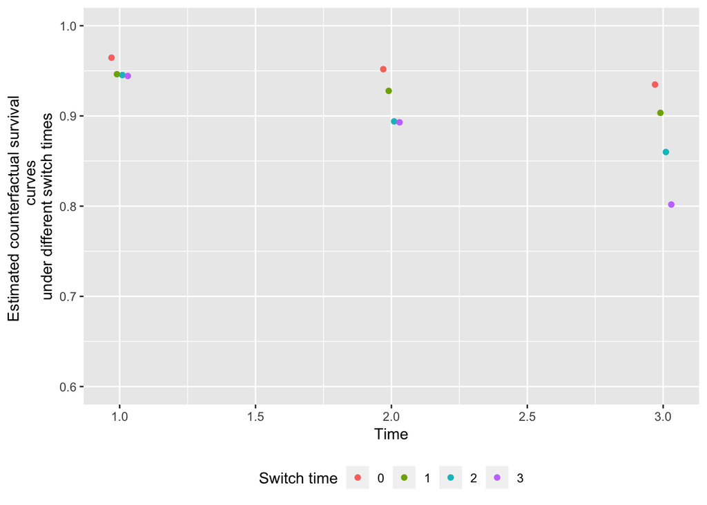

```r
## ----MSMplot, echo=FALSE, fig.width=6, fig.height=4----------------------
flat.sum.meas <- expand.grid(time = seq(1, 3, 1), switch.time = 0:3)
mm <- model.matrix(~time + pmax(time - switch.time, 0), data.frame(flat.sum.meas))
surv <- 1 - plogis(mm %*% summary(MSM.estimates)$cmat[, 1, drop = FALSE])

# offset survival so curves don't exactly overlap
df <- data.frame(surv = surv[, 1],
                 surv.off = surv[, 1] - 0.001 * flat.sum.meas$switch.time,
                 flat.sum.meas)

df <- transform(df, plot.time = time + (switch.time - 1.5)/50)

p <- qplot(x = plot.time, y = surv.off, data = df,
           color = factor(switch.time), geom = "point",
           xlab = "Time", ylab = "Estimated counterfactual survival
           curves\nunder different switch times") +
  scale_color_discrete(name = "Switch time") +
  theme(legend.position = "bottom") +
  scale_y_continuous(limits = c(0.6, 1),
                     breaks = c(0.6, 0.7, 0.8, 0.9, 1))

p
```

# 3 Longitudinal example

```r
# Example 2: Longitudinal example. Includes informative censoring and treatment.
# Time ordering of data is W, C1, L1, A1, Y1, C2, L2, A2, Y2
# True value of E[Y_(1,1,1,1)] (expected value of Y setting C1, A1, C2, A2 all to 1)
#  is approximately 0.413.
# A1 is known to always be 1 if L1 < -2, and is 1 with probability 0.1 if L1 > 2
# A2 is known to always be 1 if A1 is 1
# We incorporate this knowledge using deterministic.g.function
# Generate data:
set.seed(2)
ua <- rep(TRUE, n)   #ua = uncensored and alive
L1 <- A1 <- Y1 <- C2.binary <- L2 <- A2 <- Y2 <- as.numeric(rep(NA, n))
W <- rnorm(n)
C1 <- BinaryToCensoring(is.uncensored=rexpit(2 + W))
ua <- ua & C1 == "uncensored"
L1[ua] <- rnorm(n)[ua] + W[ua]
A1[ua] <- rexpit(L1[ua])
A1[ua & L1 < -2] <- 1
A1[ua & L1 >  2] <- rbinom(n, size=1, prob=0.1)[ua & L1 >  2]
Y1[ua] <- rexpit((W + L1 - A1)[ua])
ua <- ua & !Y1
C2.binary[ua] <- rexpit((1 + 0.7 * L1 - A1)[ua])
C2 <- BinaryToCensoring(is.uncensored=C2.binary)
ua <- ua & C2 == "uncensored"
L2[ua] <- (0.5 * L1 - 0.9 * A1 + rnorm(n))[ua]
A2[ua] <- rexpit((0.5 * L1 + 0.8 * L2)[ua]) | A1[ua]
Y2[ua] <- rexpit((0.7 * L1 + L2 - 0.8 * A1 - A2)[ua])
Y2[Y1 == 1] <- 1  # if a patient dies at time 1, record death at time 2 as well
data <- data.frame(W, C1, L1, A1, Y1, C2, L2, A2, Y2)
deterministic.g.function <- function(data, current.node, nodes) {
      if (names(data)[current.node] == "A1") {
        det <- (data$L1 < -2 | data$L1 > 2) & !is.na(data$L1)
        prob1 <- ((data$L1 < -2) * 1 + (data$L1 > 2) * 0.1)[det]
      } else if (names(data)[current.node] == "A2") {
        det <- data$A1 == 1 & !is.na(data$A1)
        prob1 <- 1
      } else if (names(data[current.node]) %in% c("C1", "C2")){
        return(NULL) #this returns the default of no deterministic links
        #note that it is not necessary to specify that prior censoring indicates future censoring
      } else {
        stop("unexpected current.node")
        }
      return(list(is.deterministic=det, prob1=prob1))
}

result2 <- ltmle(data, Anodes=c("A1","A2"), Cnodes=c("C1", "C2"),
                Lnodes=c("L1", "L2"), Ynodes=c("Y1", "Y2"), abar=c(1, 1),
                deterministic.g.function=deterministic.g.function,
                survivalOutcome=TRUE)
```

```
#> Qform not specified, using defaults:
#> formula for L1:
#> Q.kplus1 ~ W
#> formula for Y1:
#> Q.kplus1 ~ W + L1 + A1
#> formula for L2:
#> Q.kplus1 ~ W + L1 + A1
#> formula for Y2:
#> Q.kplus1 ~ W + L1 + A1 + L2 + A2
#>
#> gform not specified, using defaults:
#> formula for C1:
#> C1 ~ W
#> formula for A1:
#> A1 ~ W + L1
#> formula for C2:
#> C2 ~ W + L1 + A1
#> formula for A2:
#> A2 ~ W + L1 + A1 + L2
#>
#> Estimate of time to completion: < 1 minute
```

```r
summary(result2)
```

```
#> Estimator:  tmle
#> Call:
#> ltmle(data = data, Anodes = c("A1", "A2"), Cnodes = c("C1", "C2"),
#>     Lnodes = c("L1", "L2"), Ynodes = c("Y1", "Y2"), survivalOutcome = TRUE,
#>     abar = c(1, 1), deterministic.g.function = deterministic.g.function)
#>
#>    Parameter Estimate:  0.43048
#>     Estimated Std Err:  0.029198
#>               p-value:  <2e-16
#>     95% Conf Interval: (0.37325, 0.48771)
```

```r
# Example 3: Dynamic treatment, observation weights
# W -> A1 -> L -> A2 -> Y
# Treatment regime of interest is: Always treat at time 1 (A1 = 1),
#   treat at at time 2 (A2 = 1), iff L > 0
# Weight by pmax(W + 2, 0)
set.seed(2)
n <- 1000
W <- rnorm(n)
A1 <- rexpit(W)
L <- 0.3 * W + 0.2 * A1 + rnorm(n)
A2 <- rexpit(W + A1 + L)
Y <- rexpit(W - 0.6 * A1 + L - 0.8 * A2)
data <- data.frame(W, A1, L, A2, Y)
abar <- matrix(nrow=n, ncol=2)
abar[, 1] <- 1
abar[, 2] <- L > 0
result3 <- ltmle(data, Anodes=c("A1", "A2"), Lnodes="L", Ynodes="Y",
                 survivalOutcome=TRUE, abar=abar,
                 observation.weights = pmax(W + 2, 0))
```

```
#> Qform not specified, using defaults:
#> formula for L:
#> Q.kplus1 ~ W + A1
#> formula for Y:
#> Q.kplus1 ~ W + A1 + L + A2
#>
#> gform not specified, using defaults:
#> formula for A1:
#> A1 ~ W
#> formula for A2:
#> A2 ~ W + A1 + L
#>
#> Estimate of time to completion: < 1 minute
```

```r
summary(result3)
```

```
#> Estimator:  tmle
#> Call:
#> ltmle(data = data, Anodes = c("A1", "A2"), Lnodes = "L", Ynodes = "Y",
#>     survivalOutcome = TRUE, abar = abar, observation.weights = pmax(W +
#>         2, 0))
#>
#>    Parameter Estimate:  0.48097
#>     Estimated Std Err:  0.032972
#>               p-value:  <2e-16
#>     95% Conf Interval: (0.41635, 0.5456)
```

```r
# Example 3.1: The regime can also be specified as a rule function
rule <- function(row) c(1, row["L"] > 0)
result.rule <- ltmle(data, Anodes=c("A1", "A2"), Lnodes="L", Ynodes="Y",
                     survivalOutcome=TRUE, rule=rule,
                     observation.weights = pmax(W + 2, 0))
```

```
#> Qform not specified, using defaults:
#> formula for L:
#> Q.kplus1 ~ W + A1
#> formula for Y:
#> Q.kplus1 ~ W + A1 + L + A2
#>
#> gform not specified, using defaults:
#> formula for A1:
#> A1 ~ W
#> formula for A2:
#> A2 ~ W + A1 + L
#>
#> Estimate of time to completion: < 1 minute
```

```r
# This should be the same as the above result
summary(result.rule)
```

```
#> Estimator:  tmle
#> Call:
#> ltmle(data = data, Anodes = c("A1", "A2"), Lnodes = "L", Ynodes = "Y",
#>     survivalOutcome = TRUE, rule = rule, observation.weights = pmax(W +
#>         2, 0))
#>
#>    Parameter Estimate:  0.48097
#>     Estimated Std Err:  0.032972
#>               p-value:  <2e-16
#>     95% Conf Interval: (0.41635, 0.5456)
```

```r
# Example 4: Deterministic Q function
# W -> A1 -> Y1 -> L2 -> A2 -> Y2
set.seed(2)
n <- 200
L2 <- A2 <- Y2 <- as.numeric(rep(NA, n))
W <- rnorm(n)
A1 <- rexpit(W)
Y1 <- rexpit(W - A1)
alive <- Y1 == 0
L2[alive] <- (0.5 * W - 0.9 * A1 + rnorm(n))[alive]
completed.study <- alive & L2 > 0
#Specify that Q is deterministically 0 when L2 is in the history of the
# current Q regression and L2 > 0
#Note 1: det.Q.fun doesn't condition on called.from.estimate.g so g will also be set
# deterministically after L2 > 0
#Note 2: It is not necessary to specify that Q is deterministically 1 if Y1 is 1; this is automatic
det.Q.fun.4a <- function(data, current.node, nodes, called.from.estimate.g) {
  L2.index <- which(names(data) == "L2")
  stopifnot(length(L2.index) == 1)
  L2.in.history <- L2.index < current.node
  if (! L2.in.history) return(NULL)
  is.deterministic <- data$L2 > 0 & !is.na(data$L2)
  return(list(is.deterministic=is.deterministic, Q.value=0))
}

#patients don't change treatment after leaving study; leave their A2 as NA
A2[alive & !completed.study] <- rexpit((0.5 * W + 0.8 * L2)[alive & !completed.study])
Y2[alive & !completed.study] <- rexpit((L2 - 0.8 * A1 - A2)[alive & !completed.study])
Y2[alive & completed.study] <- 0
Y2[!alive] <- 1  # if a patient dies at time 1, record death at time 2 as well
data <- data.frame(W, A1, Y1, L2, A2, Y2)
result4a <- ltmle(data, Anodes=c("A1","A2"), Lnodes="L2",
                  Ynodes=c("Y1", "Y2"), abar=c(1, 1),
                  SL.library=NULL, estimate.time=FALSE,
                  deterministic.Q.function=det.Q.fun.4a,
                  survivalOutcome=TRUE)
```

```
#> Qform not specified, using defaults:
#> formula for Y1:
#> Q.kplus1 ~ W + A1
#> formula for Y2:
#> Q.kplus1 ~ W + A1 + L2 + A2
#>
#> gform not specified, using defaults:
#> formula for A1:
#> A1 ~ W
#> formula for A2:
#> A2 ~ W + A1 + L2
#>
```